# An Investigation of US Flights from 2008

### Investigation Overview

```
The flight data may provide insight into what time of year to avoid traveling within the US based on delays and cancellations. We can also investigate where, or which airports, offer the best (or worst) flight experiences based on similar issues. Additionally, it may be interesting to understand why flights that are cancelled get cancelled and how long a delay take before becoming a cancellation.
```

#### Dataset Overview

```
This data consists of about 7 million flights that were scheduled to occur in the US during the year 2008. Various features describing each flight include scheduled and actual departure and arrival datetimes, origin and destination airports, distance traveled, cancellation details, and more.
```

```python
import pandas as pd
import numpy as np
import matplotlib.pyplot as plt
import seaborn as sb
%matplotlib inline
import warnings
warnings.filterwarnings('ignore')
```

```python
df = pd.read_csv('cleaned_flights.csv')
df.head()
```

|  | Unnamed: 0 | Year | Month | DayofMonth | DayOfWeek | DepTime | CRSDepTime | ArrTime | CRSArrTime | UniqueCarrier | ... | TaxiOut | Cancelled | CancellationCode | Diverted | CarrierDelay | WeatherDelay | NASDelay | SecurityDelay | LateAircraftDelay | CRSDepTimeHour |
| --- | --- | --- | --- | --- | --- | --- | --- | --- | --- | --- | --- | --- | --- | --- | --- | --- | --- | --- | --- | --- | --- |
| 0 | 0 | 2008 | 1 | 3 | 4 | 20:03:00 | 19:55:00 | 22:11:00 | 22:25:00 | WN | ... | 8.0 | 0 | E | 0 | 0.0 | 0.0 | 0.0 | 0.0 | 0.0 | 19 |
| 1 | 1 | 2008 | 1 | 3 | 4 | 07:54:00 | 07:35:00 | 10:02:00 | 10:00:00 | WN | ... | 10.0 | 0 | E | 0 | 0.0 | 0.0 | 0.0 | 0.0 | 0.0 | 7 |
| 2 | 2 | 2008 | 1 | 3 | 4 | 06:28:00 | 06:20:00 | 08:04:00 | 07:50:00 | WN | ... | 17.0 | 0 | E | 0 | 0.0 | 0.0 | 0.0 | 0.0 | 0.0 | 6 |
| 3 | 3 | 2008 | 1 | 3 | 4 | 09:26:00 | 09:30:00 | 10:54:00 | 11:00:00 | WN | ... | 7.0 | 0 | E | 0 | 0.0 | 0.0 | 0.0 | 0.0 | 0.0 | 9 |
| 4 | 4 | 2008 | 1 | 3 | 4 | 18:29:00 | 17:55:00 | 19:59:00 | 19:25:00 | WN | ... | 10.0 | 0 | E | 0 | 2.0 | 0.0 | 0.0 | 0.0 | 32.0 | 17 |

5 rows × 31 columns

## How many flights were cancelled in 2008?

### Cancelled vs Not Cancelled Flights

```python
cc = df['Cancelled'].value_counts()
cc
```

```
0    6855027
1     137434
Name: Cancelled, dtype: int64
```

[figure not shown]

```python
base_color = sb.color_palette()[0]
ax = sb.countplot(data = df, x = 'Cancelled',
             color = base_color);
plt.ylim([0, 7500000])

# add annotations
n = df.shape[0]
cat_counts = df['Cancelled'].value_counts()
locs, labels = plt.xticks() # get the current tick locations and labels
cat_counts
# loop through each pair of locations and labels
for loc, label in zip(locs, labels):
    # get the text property for the label to get the correct count
    count = cat_counts[int(label.get_text())]
    ct_string = '{:0.2f}%'.format(count/n)
    plt.text(loc, count+100000, ct_string, ha = 'center', color = 'k')

plt.xticks([0, 1], ['Not Cancelled', 'Cancelled']);
plt.title('Distribution of Cancellations by Code', fontsize=15);
```

A large majority of flights were successful, while only a small number were cancelled. We'll mainly focus on just the cancelled flights (or relative number of cancelled flights by category) to see if we can determine where (by airline) most flights are cancelled, why (by cancellation code), and when (by month).

#### Subsets of Cancelled or Not Cancelled Flights

```python
# Create a subset of the data for cancelled flights:
df_cancelled = df.query('(Cancelled==1)')
df_notcancelled = df.query('(Cancelled==0)')
print('There were {:0.0f} cancelled flights out of {:0.0f} total flights in 2008'.format(df_cancelled.shape[0], df.shape[0]))
```

```
There were 137434 cancelled flights out of 6992461 total flights in 2008
```

### What is the most common reason for cancellation?

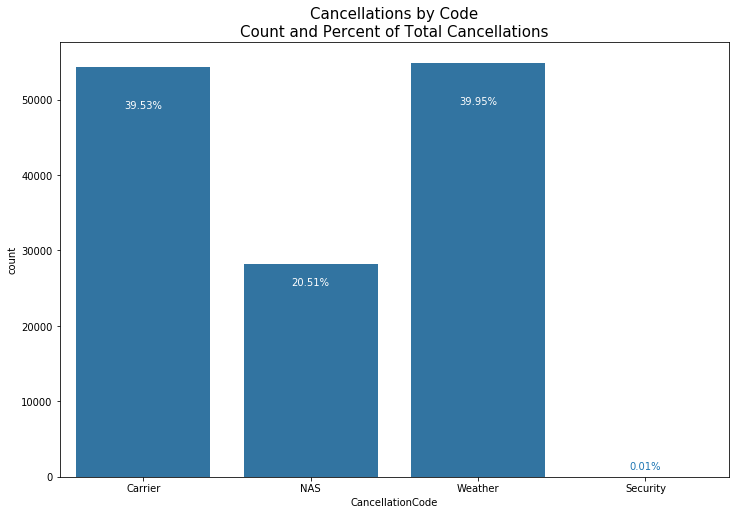

```python
plt.figure(figsize=(12,8));
# Distribution of cancellation codes
cancel_codes = ['Carrier', 'NAS', 'Weather', 'Security']
locs = range(4)
base_color = sb.color_palette()[0]
ax = sb.countplot(data = df_cancelled, x = 'CancellationCode',
             color = base_color);

# add annotations
n_points = df_cancelled.shape[0]
cat_counts = df_cancelled['CancellationCode'].value_counts()
locs, labels = plt.xticks() # get the current tick locations and labels

# loop through each pair of locations and labels
for loc, label in zip(locs, labels):
    # get the text property for the label to get the correct count
    count = cat_counts[label.get_text()]
    pct_string = '{:0.2f}%'.format(100*count/n_points)
    if count > 2000:
        # print the annotation just below the top of the bar
        plt.text(loc, 0.9*count, pct_string, ha = 'center', color = 'w')
    else:
        plt.text(loc, 1000, pct_string, ha = 'center', color = base_color)

plt.xticks(locs, cancel_codes);
plt.title('Cancellations by Code\nCount and Percent of Total Cancellations', fontsize=15);
```

Carrier and Weather are nearly tied for the most common causes of cancellations. Security makes up only 0.01% of all cancellations, while NAS falls somewhere in the middle at about 1/5 of all cancellations. It may be interesting to see if Carrier and Weather are also correlated with Origin Airports, such that airports in certain locations are more susceptible to poor weather and typically fly planes from certain carriers.

### Where do cancellations occur?

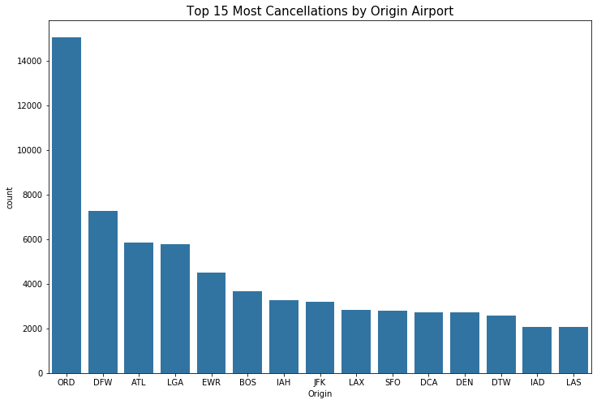

```python
# Cancellations by Airports - most cancellations
base_color = sb.color_palette()[0]

top = (df_cancelled.Origin.value_counts()[0:15].index)
plt.figure(figsize=(12,8))
ax = sb.countplot(data = df_cancelled[df_cancelled.Origin.isin(top)], x='Origin',
             color = base_color, order=top);
plt.title('Top 15 Most Cancellations by Origin Airport', fontsize=15);
```

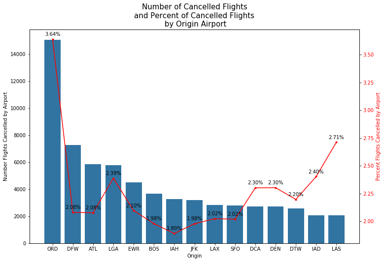

```python
# % Cancelled Flights for the Top 15 Origina Airports with most cancellations
# ie. for each airport, the percentage of cancelled flights relative to that airport's total flights
# top = airport labels
top = (df_cancelled.Origin.value_counts()[0:15].index)
fig, ax1 = plt.subplots(figsize=(12,8))

ax1 = sb.countplot(data = df_cancelled[df_cancelled.Origin.isin(top)], x='Origin',
             color = base_color, order=top);

n_points = df[df.Origin.isin(top)].Origin.value_counts().values
n_cancels = df_cancelled[df_cancelled.Origin.isin(top)].Origin.value_counts().values
locs = range(15)
locslabs = sorted(zip(locs, top, n_cancels, n_points), key=lambda x: x[1])

plt.title('Number of Cancelled Flights\nand Percent of Cancelled Flights\n by Origin Airport', fontsize=15);
ax1.set_ylabel('Number Flights Cancelled by Airport', color='k')  # we already handled the x-label with ax1

ax2 = ax1.twinx()  # instantiate a second axes that shares the same x-axis
pct_cnl = 100* n_cancels/ n_points
# locs remains the same
ax2.plot(locs, pct_cnl, color='r', marker='.')
ax2.set_ylabel('Percent Flights Cancelled by Airport', color='r')  # we already handled the x-label with ax1
ax2.tick_params(axis='y', labelcolor='r')
for loc, label, can, tot in locslabs:
    pct_str = '{:0.2f}%'.format(100*can/tot)
    plt.text(loc, 100*can/tot+0.03, pct_str, ha='center', color='k')
```

### Where were flights cancelled broken down by cancellation code?

To highlight the differences in number of cancelled flights by airport (because the previous plot mainly demonstrated volume of all flights and the percent of cancellations per airport) we will focus on only numbers of cancelled flights per airport, broken down by cancellation reasons.

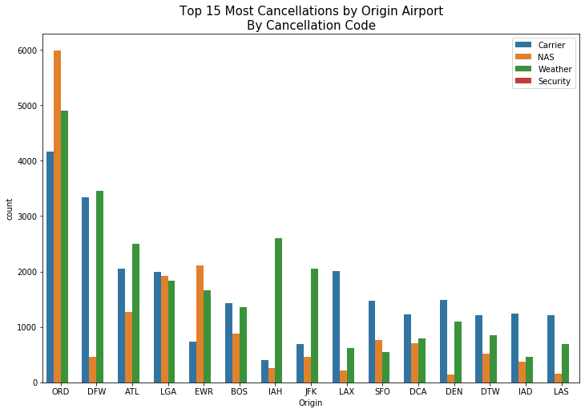

```python
# Cancellations by Airports and codes - most cancellations
base_color = sb.color_palette()[0]

top = (df_cancelled.Origin.value_counts()[0:15].index)
plt.figure(figsize=(12,8))
ax = sb.countplot(data = df_cancelled[df_cancelled.Origin.isin(top)], x='Origin',
             hue = 'CancellationCode', order=top);
plt.title('Top 15 Most Cancellations by Origin Airport\nBy Cancellation Code', fontsize=15);

plt.legend(['Carrier','NAS','Weather','Security']);
```

Although NAS can refer to weather as well, we will keep NAS and Weather separate and will distinguish the two, knowing that Weather related to Extreme Weather, while NAS may be more common weather scenarios. Aside from Chicago (ORD) and Newark (EWR), most of the top volume airports experience cancellations due to Carrier and Weather issues. However, considering that Chicago and Newark often experience snow during the winter, many of their NAS cancellations may also be caused by weather.

## When do Cancelled flights occur?

##### By Month

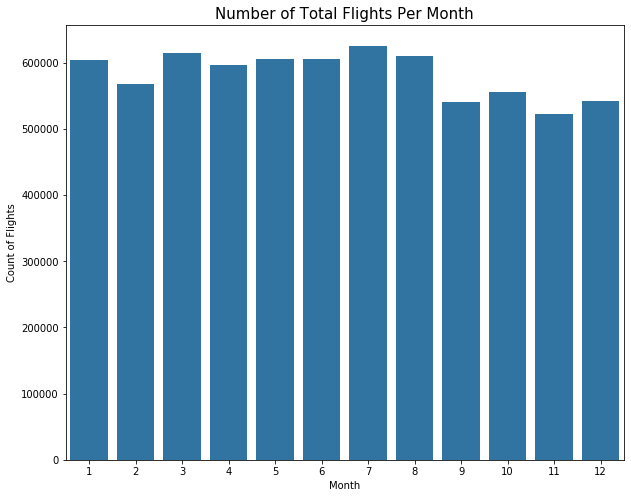

```python
plt.figure(figsize=(10,8))
sb.countplot(data=df, x='Month', color=base_color);
plt.title("Number of Total Flights Per Month", fontsize=15);
plt.ylabel("Count of Flights");
```

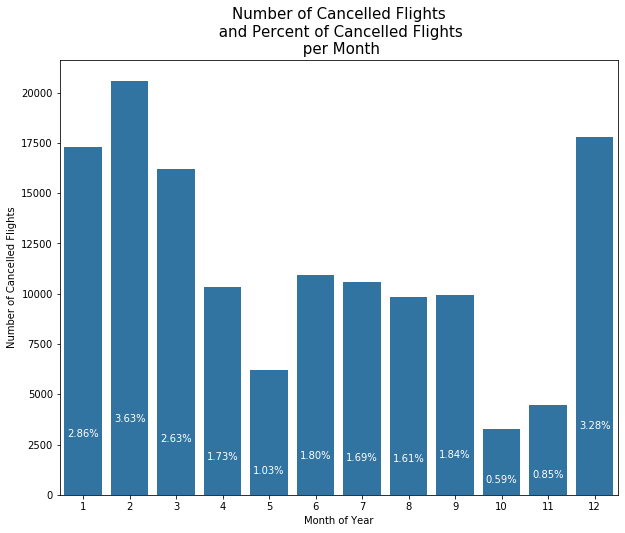

```python
# Cancellations by month
plt.figure(figsize=(10,8))
sb.countplot(data=df_cancelled, x='Month', color=base_color);

tot_flights = df.Month.value_counts().sort_index().values
can_flights = df_cancelled.Month.value_counts().sort_index().values
locs = range(1,13)
locslabs = zip(locs, can_flights, tot_flights)

for loc, can, tot in locslabs:
    pct = 100*can/tot
    pct_str = '{:0.2f}%'.format(pct)
    plt.text(loc-1, pct*1000, pct_str, ha='center', color='w')

# plt.plot();
# plt.legend(['Percent Cancelled'], markerfirst=False, facecolor='w', scatterpoints=0);
plt.ylabel('Number of Cancelled Flights');
plt.xlabel('Month of Year');
plt.title('Number of Cancelled Flights\n and Percent of Cancelled Flights\n per Month', fontsize=15);
```

The most cancellations and the highest percentage of cancellations occur over the months of December, January, February, and March. This aligns with the findings above that most cancellations are related to weather or carrier. It would be interesting to see what types of cancellations occur during each month.

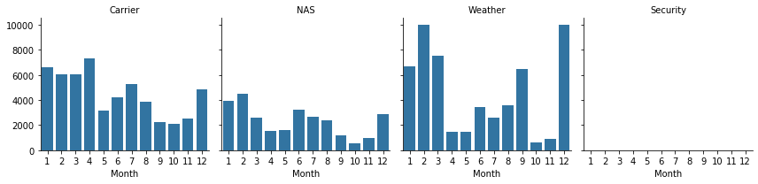

```python
# Cancellation codes by month
df_cancelled['CancellationReason'] = df_cancelled['CancellationCode'].replace({'A': 'Carrier',
                                                              'B': 'Weather',
                                                               'C': 'NAS',
                                                                 'D': 'Security'})

g = sb.FacetGrid(df_cancelled, col="CancellationReason")
g = g.map(sb.countplot, "Month", order=[1,2,3,4,5,6,7,8,9,10,11,12]).set_titles("{col_name}")
```

In the US, the most common delays over the winter/holiday months seems to be due to weather, followed by carrier, which is fairly consistent across all other months. NAS causes fewer cancellations, but also has slightly higher volumes during the winter months, which could also relate back to the weather sub-reason. Since there are only 12 examples of Security reasons causing cancellations those results are negligible.

##### By Day of Week

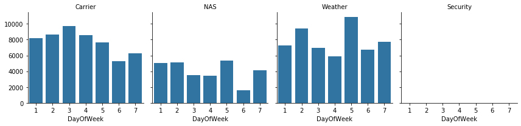

```python
# Day of Week for Each Cancellation Code
g = sb.FacetGrid(df_cancelled, col="CancellationReason")
g = g.map(sb.countplot, "DayOfWeek", order=[1,2,3,4,5,6,7]).set_titles("{col_name}")
```

### Does a certain carrier have more cancellations?

```python
len(df.UniqueCarrier.value_counts().index)
```

```
20
```

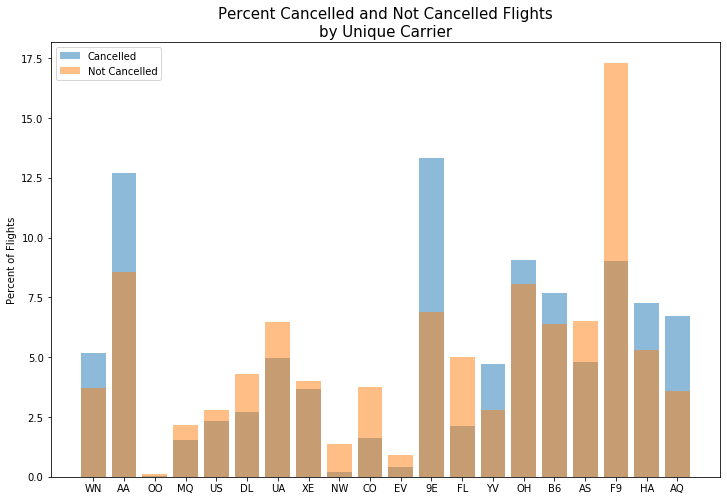

```python
plt.figure(figsize=(12,8))

n_points_can = df[df.Cancelled==1].UniqueCarrier.value_counts().sort_index().values
n_cancels = df[df.Cancelled==1].shape[0]
pct_can = n_points_can / n_cancels*100

n_points = df[df.Cancelled==0].UniqueCarrier.value_counts().sort_index().values
n_nocan = df[df.Cancelled==0].shape[0]
pct_nocan = n_points / n_nocan*100
locs = np.arange(0,20,1)

plt.bar(x=locs, height=pct_can, label='Cancelled', alpha=0.5);
plt.bar(x=locs, height=pct_nocan, label='Not Cancelled', alpha=0.5);
plt.legend();
plt.xticks(locs, list(df.UniqueCarrier.value_counts().index));

plt.title('Percent Cancelled and Not Cancelled Flights\nby Unique Carrier', fontsize=15);
plt.ylabel('Percent of Flights', color='k');  # we already handled the x-label with ax1
```

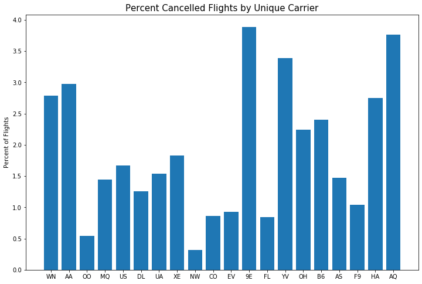

```python
plt.figure(figsize=(12,8))

n_points_can = df[df.Cancelled==1].UniqueCarrier.value_counts().sort_index().values
n_points = df[df.Cancelled==0].UniqueCarrier.value_counts().sort_index().values
pct_can = n_points_can / n_points*100

locs = np.arange(0,20,1)

plt.bar(x=locs, height=pct_can, label='Cancelled');
plt.xticks(locs, list(df.UniqueCarrier.value_counts().index));

plt.title('Percent Cancelled Flights by Unique Carrier', fontsize=15);
plt.ylabel('Percent of Flights', color='k');
```

Some carriers have a higher percentage of cancellations than others: WN, AA, 9E, YV, OH, B6, HA, AQ. These may be interesting to examine closer and see if they correlate with the cancellation code, time, distance, or departing airports which also exhibited more cancellations relatively.

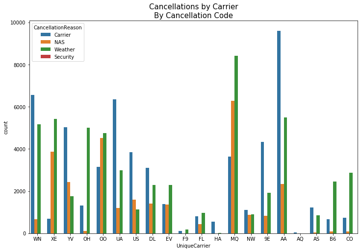

```python
# Cancellations by Carriers and codes
base_color = sb.color_palette()[0]

top = (df_cancelled.UniqueCarrier.value_counts().index)
plt.figure(figsize=(12,8))
ax = sb.countplot(data = df_cancelled, x='UniqueCarrier',
             hue = 'CancellationReason');
plt.title('Cancellations by Carrier\nBy Cancellation Code', fontsize=15);
```

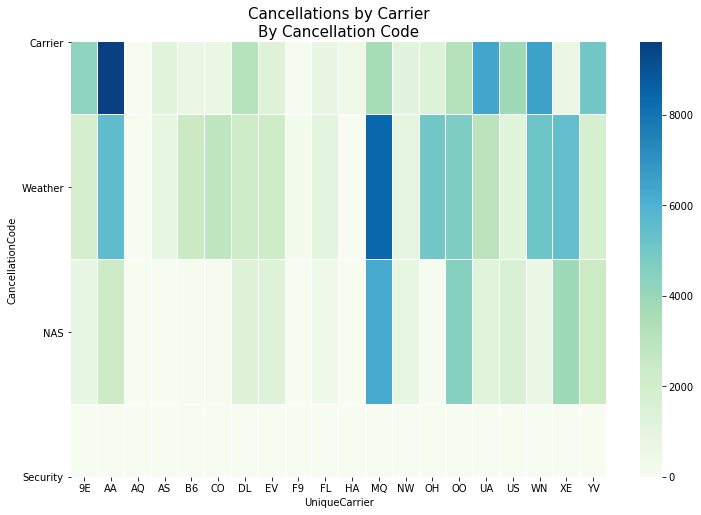

```python
# Cancellations due to Carrier and Carriers - Summation
plt.figure(figsize=(12,8))
df_sub = df_cancelled[['UniqueCarrier','CancellationCode','Cancelled']]
df_subpiv = df_sub.pivot_table(index='CancellationCode', columns='UniqueCarrier',
                               values='Cancelled', fill_value=0, aggfunc='sum')
ax = sb.heatmap(df_subpiv, cmap='GnBu', linewidths=0.01);
locs,labels = plt.yticks();
plt.yticks(locs, ['Carrier', 'Weather','NAS','Security'], rotation=0);
plt.title('Cancellations by Carrier\nBy Cancellation Code', fontsize=15);
```

### Conclusions:

The trick is that even NAS can refer to weather - it's one of the five possible sub-reasons associated with National Airport Services cancellations. Overall, the flights that had the highest chances of cancellations were those on specific carriers departing from bad weather-prone airports (such as Atlanta (with the hurricanes) and Chicago (with the snow storms)) during typically bad weather months (such as winter). Luckily, the total number of cancellations represented such a small percentage of the full volume of flights scheduled in 2008. However, this analysis does suggest that it could be relatively simple to avoid at least some cancelled flights in the future by staying away from flying when you find yourself at any of these airports and the forecast looks ominous.